# ITNPBD2 Representing and Manipulating Data

# Assignment Autumn 2025

# A Consultancy Job for JC Penney

This notebook forms the assignment instructions and submission document of the assignment for ITNPBD2. Read the instructions carefully and enter code into the cells as indicated.

- jcpenney_reviewers.json
- jcpenney_products.json
- products.csv
- reviews.csv
- users.csv
- population.csv

The data in these files describes products that have been sold by the American retail giant, JC Penney, and reviews by customers who bought them. Note that the product data is real, but the customer data is synthetic.

Your job is to process the data, as requested in the instructions in the markdown cells in this notebook.

# Completing the Assignment

Rename this file to be xxxxxx_BD2 where xxxxxx is your student number, then type your code and narrative description into the boxes provided. Add as many code and markdown cells as you need. The cells should contain:

- **Text narrative describing what you did with the data**
- **The code that performs the task you have described**
- **Comments that explain your code**

The final structure (in PDF) of your report must:

- **Start from the main insights observed (max 5 pages)**
- **Include as an appendix the source code used for producing those insights (max 15 pages)**
- **Include an AI cover sheet (provided on Canvas), which must contain a link to a versioned notebook file in OneDrive or another platform for version checks.**

# Marking Scheme

The assessment will be marked against the university Common Marking Scheme (CMS)

Here is a summary of what you need to achieve to gain a grade in the major grade bands:

| Grade | Requirement |
| --- | --- |
| Fail | You will fail if your code does not run or does not achieve even the basics of the task. You may also fail if you submit code without either comments or a text explanation of what the code does. |
| Pass | To pass, you must submit sufficient working code to show that you have mastered the basics of the task, even if not everything works completely. You must include some justifications for your choice of… |
| Merit | For a merit, your code must be mostly correct, with only small problems or parts missing, and your comments must be useful rather than simply re-stating the code in English. Most choices for methods a… |
| Distinction | For a distinction, your code must be working, correct, and well commented and shows an appreciation of style, efficiency and reliability. All choices for methods and structures are concisely justified… |

The full details of the CMS can be found here

https://www.stir.ac.uk/about/professional-services/student-academic-and-corporate-services/academic-registry/academic-policy-and-practice/quality-handbook/assessment-policy-and-procedure/appendix-2-postgraduate-common-marking-scheme/

Note that this means there are not certain numbers of marks allocated to each stage of the assignment. Your grade will reflect how well your solutions and comments demonstrate that you have achieved the learning outcomes of the task.

## Submission

When you are ready to submit, **print** your notebook as PDF (go to File -> Print Preview) in the Jupyter menu. Make sure you have run all the cells and that their output is displayed. Any lines of code or comments that are not visible in the pdf should be broken across several lines. You can then submit the file online.

Late penalties will apply at a rate of three marks per day, up to a maximum of 7 days. After 7 days you will be given a mark of 0. Extensions will be considered under acceptable circumstances outside your control.

## Academic Integrity

This is an individual assignment, and so all submitted work must be fully your own work.

The University of Stirling is committed to protecting the quality and standards of its awards. Consequently, the University seeks to promote and nurture academic integrity, support staff academic integrity, and support students to understand and develop good academic skills that facilitate academic integrity.

In addition, the University deals decisively with all forms of Academic Misconduct.

Where a student does not act with academic integrity, their work or behaviour may demonstrate Poor Academic Practice or it may represent Academic Misconduct.

### Poor Academic Practice

Poor Academic Practice is defined as: "The submission of any type of assessment with a lack of referencing or inadequate referencing which does not effectively acknowledge the origin of words, ideas, images, tables, diagrams, maps, code, sound and any other sources used in the assessment."

### Academic Misconduct

Academic Misconduct is defined as: "any act or attempted act that does not demonstrate academic integrity and that may result in creating an unfair academic advantage for you or another person, or an academic disadvantage for any other member or member of the academic community."

Plagiarism is presenting somebody else’s work as your own **and includes the use of artificial intelligence tools beyond AIAS Level 2 or the use of Large Language Models.**. Plagiarism is a form of academic misconduct and is taken very seriously by the University. Students found to have plagiarised work can have marks deducted and, in serious cases, even be expelled from the University. Do not submit any work that is not entirely your own. Do not collaborate with or get help from anybody else with this assignment.

The University of Stirling's full policy on Academic Integrity can be found at:

https://www.stir.ac.uk/about/professional-services/student-academic-and-corporate-services/academic-registry/academic-policy-and-practice/quality-handbook/academic-integrity-policy-and-academic-misconduct-procedure/

## The Assignment

Your task with this assignment is to use the data provided to demonstrate your Python data manipulation skills.

There are three `.csv` files and two `.json` files so you can process different types of data. The files also contain unstructured data in the form of natural language in English and links to images that you can access from the JC Penney website (use the field called `product_image_urls`).

Start with easy tasks to show you can read in a file, create some variables and data structures, and manipulate their contents. Then move onto something more interesting.

Look at the data that we provided with this assessment and think of something interesting to do with it using whatever libraries you like. Describe what you decide to do with the data and why it might be interesting or useful to the company to do it.

You can add additional data if you need to - either download it or access it using `requests`. Produce working code to implement your ideas in as many cells as you need below. There is no single right answer, the aim is to simply show you are competent in using python for data analysis. Exactly how you do that is up to you.

For a distinction class grade, this must show originality, creative thinking, and insights beyond what you've been taught directly on the module.

## Structure

You may structure the appendix of the project how you wish, but here is a suggested guideline to help you organise your work, based on the CRISP-DM data science methodology:

1. **Business understanding** - What business context is the data coming from? What insights would be valuable in that context, and what data would be required for that purporse?
2. **Data understanding and preparation** - Explore the data and show you understand its structure and relations, with the aid of appropriate visualisation techniques. Assess the data quality, which insights you would be able to answer from it, and what preparation the data would require. Add new data from another source if required to bring new insights to the data you already have.
3. **Data modeling (optional)** - Would modeling be required for the insights you have considered? Use appropriate techniques, if so.
4. **Evaluation and deployment** - How do the insights you obtained help the company, and how can should they be adopted in their business? If modeling techniques have been adopted, are their use scientifically sound and how should they be mantained?

# Remember to make sure you are working completely on your own.

# Don't work in a group or with a friend

**1. Data Exploration**

```python
#For proper analysing and processing of JC Penney product and the customer reviews data in Python programing language, it will be
#required to import some essential machine learning libraries to enable efficient data handling, data visualization and analysis without writing the required
#code from the beginning. Libraries like pandas which is use to analyse, manipulte and clean data using dataframe. numpy is use to support
#numerical and mathematical operations. json manages JavaScript object notation and is use to read and write structured data like API data,configs.
#OS is use to utilise and communicate with the operating system, aids in managing environment variables, directories, and file paths. CSV enables
#reading and writing of files. matplotlib.pyplot is for creating charts and graphs for visualisations. seaborn is built on matplotlib for improved
#colour schemes and styles.

#Importing pandas library
import pandas as pd
#Importing numpy library for numerical operations
import numpy as np

#Importing json library to read and write structured data
import json

#Importing os to utilise and communicate with operating system and aids in managing directories and file paths
import os

#Importing csv library to enable reading and writing of files
import csv

#Importing matplotlib.pyplot to customise and create visualisations from data
import matplotlib.pyplot as plt

#Importing season to make visualisation informative and improve colour schmes and styles
import seaborn as sns
```

**1.1 Product_json Data Exploration**

```python
#We need to check that the object keys in jcpenney_products.json are all the same. So, I'll open the file,save the keys from the first object, and
#then use a for loop to go through the other objects and compare their keys to the saved set to check for consistency
import json
consistent = True
first_keys = None

with open("/Users/mac/Documents/JCPenneyFiles/jcpenney_products.json", "r") as f:
    for uniform in f:
        keys = set(json.loads(uniform).keys())
        if first_keys is None:
            first_keys = keys
        elif keys != first_keys:
            consistent = False
            break
if uniform:
    print('True')
else:
    print('False')
```

```
True
```

```python
#Reading the products.json file and convert the data to a structured dataframe
products_json_df = pd.read_json("/Users/mac/Documents/JCPenneyFiles/jcpenney_products.json", lines=True)

#Show the first two rows including the columns of the dataframe to view the records
print(products_json_df.head(2))
```

```
                            uniq_id           sku  \
0  b6c0b6bea69c722939585baeac73c13d  pp5006380337
1  93e5272c51d8cce02597e3ce67b7ad0a  pp5006380337

                                    name_title  \
0  Alfred Dunner® Essential Pull On Capri Pant
1  Alfred Dunner® Essential Pull On Capri Pant

                                         description list_price sale_price  \
0  You'll return to our Alfred Dunner pull-on cap...      41.09      24.16
1  You'll return to our Alfred Dunner pull-on cap...      41.09      24.16

        category                 category_tree  average_product_rating  \
0  alfred dunner  jcpenney|women|alfred dunner                   2.625
1  alfred dunner  jcpenney|women|alfred dunner                   3.000

                                         product_url  \
0  http://www.jcpenney.com/alfred-dunner-essentia...
1  http://www.jcpenney.com/alfred-dunner-essentia...

                                  product_image_urls          brand  \
0  http://s7d9.scene7.com/is/image/JCPenney/DP122...  Alfred Dunner
1  http://s7d9.scene7.com/is/image/JCPenney/DP122...  Alfred Dunner

   total_number_reviews                                            Reviews  \
0                     8  [{'User': 'fsdv4141', 'Review': 'You never hav...
1                     8  [{'User': 'tpcu2211', 'Review': 'You never hav...

                                         Bought With
0  [898e42fe937a33e8ce5e900ca7a4d924, 8c02c262567...
1  [bc9ab3406dcaa84a123b9da862e6367d, 18eb69e8fc2...
```

```python
#This gives a concise overview of products.json dataframe
products_json_df.info()
```

```
<class 'pandas.core.frame.DataFrame'>
RangeIndex: 7982 entries, 0 to 7981
Data columns (total 15 columns):
 #   Column                  Non-Null Count  Dtype
---  ------                  --------------  -----
 0   uniq_id                 7982 non-null   object
 1   sku                     7982 non-null   object
 2   name_title              7982 non-null   object
 3   description             7982 non-null   object
 4   list_price              7982 non-null   object
 5   sale_price              7982 non-null   object
 6   category                7982 non-null   object
 7   category_tree           7982 non-null   object
 8   average_product_rating  7982 non-null   float64
 9   product_url             7982 non-null   object
 10  product_image_urls      7982 non-null   object
 11  brand                   7982 non-null   object
 12  total_number_reviews    7982 non-null   int64
 13  Reviews                 7982 non-null   object
 14  Bought With             7982 non-null   object
dtypes: float64(1), int64(1), object(13)
memory usage: 935.5+ KB
```

**1.2 Reviewer_json Data Exploration**

```python
#We need to check that the object keys in reviewers.json are all the same. So, I'll open the file,save the keys from the first object, and
#then use a for loop to go through the other objects and compare their keys to the saved set to check for consistency
import json
consistent = True
first_keys = None

with open("/Users/mac/Documents/JCPenneyFiles/jcpenney_reviewers.json", "r") as f:
    for uniform in f:
        keys = set(json.loads(uniform).keys())
        if first_keys is None:
            first_keys = keys
        elif keys != first_keys:
            uniform = False
            break
print("True" if uniform else "False")
```

```
True
```

```python
#Reading the reviewers.json file and convert the data to a structured dataframe
reviewers_json_df = pd.read_json("/Users/mac/Documents/JCPenneyFiles/jcpenney_reviewers.json", lines=True)

#Show the first two rows including the columns of the dataframe to view the records
print(reviewers_json_df.head(2))
```

```
   Username         DOB          State                            Reviewed
0  bkpn1412  31.07.1983         Oregon  [cea76118f6a9110a893de2b7654319c0]
1  gqjs4414  27.07.1998  Massachusetts  [fa04fe6c0dd5189f54fe600838da43d3]
```

```python
#This gives a concise overview of reviewers.json dataframe
reviewers_json_df.info()
```

```
<class 'pandas.core.frame.DataFrame'>
RangeIndex: 5000 entries, 0 to 4999
Data columns (total 4 columns):
 #   Column    Non-Null Count  Dtype
---  ------    --------------  -----
 0   Username  5000 non-null   object
 1   DOB       5000 non-null   object
 2   State     5000 non-null   object
 3   Reviewed  5000 non-null   object
dtypes: object(4)
memory usage: 156.4+ KB
```

**1.3 Products_csv Data Exploration**

```python
#Read the products.csv into pandas dataframe for analysis
products_csv_df = pd.read_csv("/Users/mac/Documents/JCPenneyFiles/products.csv")
```

```python
#Print the columns with the top two rows of the products.csv dataframe
products_csv_df.head(2)
```

|  | Uniq_id | SKU | Name | Description | Price | Av_Score |
| --- | --- | --- | --- | --- | --- | --- |
| 0 | b6c0b6bea69c722939585baeac73c13d | pp5006380337 | Alfred Dunner® Essential Pull On Capri Pant | Youll return to our Alfred Dunner pull-on capr... | 41.09 | 2.625 |
| 1 | 93e5272c51d8cce02597e3ce67b7ad0a | pp5006380337 | Alfred Dunner® Essential Pull On Capri Pant | Youll return to our Alfred Dunner pull-on capr... | 41.09 | 3.000 |

```python
#This shows the dimension of the product.csv dataframe in terms of rows and columns
products_csv_df.shape
```

```
(7982, 6)
```

```python
#This gives a concise overview of products.csv dataframe
products_csv_df.info()
```

```
<class 'pandas.core.frame.DataFrame'>
RangeIndex: 7982 entries, 0 to 7981
Data columns (total 6 columns):
 #   Column       Non-Null Count  Dtype
---  ------       --------------  -----
 0   Uniq_id      7982 non-null   object
 1   SKU          7915 non-null   object
 2   Name         7982 non-null   object
 3   Description  7439 non-null   object
 4   Price        5816 non-null   float64
 5   Av_Score     7982 non-null   float64
dtypes: float64(2), object(4)
memory usage: 374.3+ KB
```

```python
#This show the product.csv dataframe columns
products_csv_df.columns
```

```
Index(['Uniq_id', 'SKU', 'Name', 'Description', 'Price', 'Av_Score'], dtype='object')
```

```python
#This display and calculate the statistical summary of products_csv for the numeric columns in the dataframe using describe function
products_csv_df.describe()
```

|  | Price | Av_Score |
| --- | --- | --- |
| count | 5816.000000 | 7982.000000 |
| mean | 144.776618 | 2.988683 |
| std | 499.223719 | 0.911673 |
| min | -65.270000 | 1.000000 |
| 25% | 40.700000 | 2.500000 |
| 50% | 58.010000 | 3.000000 |
| 75% | 87.020000 | 3.500000 |
| max | 17122.170000 | 5.000000 |

**1.4 Reviews_csv Data Exploration**

```python
#Reading the products.csv file and convert to dataframe for analysis
reviews_csv_df = pd.read_csv("/Users/mac/Documents/JCPenneyFiles/reviews.csv")
```

```python
##Print the columns with the top two rows of the reviews.csv dataframe
reviews_csv_df.head(2)
```

|  | Uniq_id | Username | Score | Review |
| --- | --- | --- | --- | --- |
| 0 | b6c0b6bea69c722939585baeac73c13d | fsdv4141 | 2 | You never have to worry about the fit...Alfred... |
| 1 | b6c0b6bea69c722939585baeac73c13d | krpz1113 | 1 | Good quality fabric. Perfect fit. Washed very ... |

```python
#This shows the dimension of the reviews.csv dataframe in terms of rows and columns
reviews_csv_df.shape
```

```
(39063, 4)
```

```python
#This gives a concise overview of reviews.csv dataframe
reviews_csv_df.info()
```

```
<class 'pandas.core.frame.DataFrame'>
RangeIndex: 39063 entries, 0 to 39062
Data columns (total 4 columns):
 #   Column    Non-Null Count  Dtype
---  ------    --------------  -----
 0   Uniq_id   39063 non-null  object
 1   Username  39063 non-null  object
 2   Score     39063 non-null  int64
 3   Review    39063 non-null  object
dtypes: int64(1), object(3)
memory usage: 1.2+ MB
```

```python
#This display and calculate the statistical summary of reviews_csv for the numeric columns in the dataframe using describe function
reviews_csv_df.describe()
```

|  | Score |
| --- | --- |
| count | 39063.000000 |
| mean | 1.487648 |
| std | 1.400332 |
| min | 0.000000 |
| 25% | 0.000000 |
| 50% | 1.000000 |
| 75% | 2.000000 |
| max | 5.000000 |

```python
#This show the reviews.csv dataframe columns
reviews_csv_df.columns
```

```
Index(['Uniq_id', 'Username', 'Score', 'Review'], dtype='object')
```

**1.5 Users_csv Data Exploration**

```python
#Reading the products.csv file and convert to dataframe for analysis
users_csv_df = pd.read_csv("/Users/mac/Documents/JCPenneyFiles/users.csv")
```

```python
##Print the columns with the top two rows of the users.csv dataframe
users_csv_df.head(2)
```

|  | Username | DOB | State |
| --- | --- | --- | --- |
| 0 | bkpn1412 | 31.07.1983 | Oregon |
| 1 | gqjs4414 | 27.07.1998 | Massachusetts |

```python
#This shows the dimension of the users.csv dataframe in terms of rows and columns
users_csv_df.shape
```

```
(5000, 3)
```

```python
#This gives a concise overview of users.csv dataframe
users_csv_df.info()
```

```
<class 'pandas.core.frame.DataFrame'>
RangeIndex: 5000 entries, 0 to 4999
Data columns (total 3 columns):
 #   Column    Non-Null Count  Dtype
---  ------    --------------  -----
 0   Username  5000 non-null   object
 1   DOB       5000 non-null   object
 2   State     5000 non-null   object
dtypes: object(3)
memory usage: 117.3+ KB
```

```python
#This display and calculate the statistical summary of describe_csv for the numeric columns in the dataframe using describe function
users_csv_df.describe()
```

|  | Username | DOB | State |
| --- | --- | --- | --- |
| count | 5000 | 5000 | 5000 |
| unique | 4999 | 52 | 57 |
| top | dqft3311 | 07.08.1953 | Massachusetts |
| freq | 2 | 112 | 107 |

```python
#This print out the users_csv dataframe columns
users_csv_df.columns
```

```
Index(['Username', 'DOB', 'State'], dtype='object')
```

**2. Data Validation**

```python
#The double quotation checks for empty strings in the given data frame. It replaces with nan (not a number) which is pandas method of representing
#missing values. The inplace=True as seen implies the adjustment is done directly in the dataframe. The isnull finds the missing values for an
#array lookalike object in the cell and the dot sum count the number of missing value for each columns if there is

# Checking for missing value in products_json_df file and print the total number of missing values on each
products_json_df.replace('', np.nan, inplace=True)

#Output the number of missing values on each column if it's available
print(products_json_df.isnull().sum())
```

```
uniq_id                      0
sku                         67
name_title                   0
description                543
list_price                2166
sale_price                  18
category                   636
category_tree              636
average_product_rating       0
product_url                  0
product_image_urls         157
brand                        0
total_number_reviews         0
Reviews                      0
Bought With                  0
dtype: int64
```

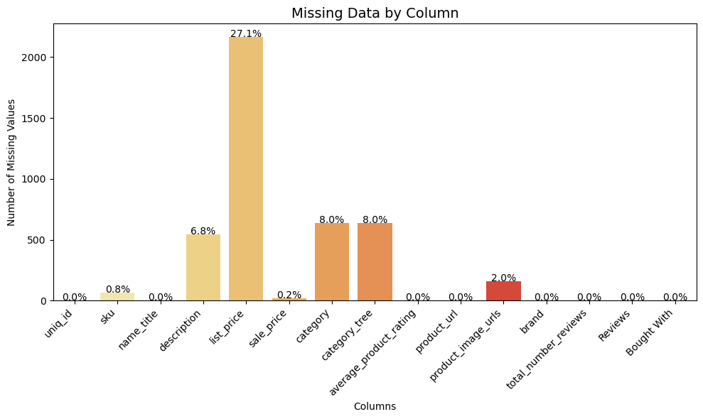

```python
#Looping through the column and count the missing values
missing_values = products_json_df.isnull().sum()
total_rows = len(products_json_df)

#print the plot in a bar chart form to display the missing values in each columns
plt.figure(figsize=(10, 6))
ax = sns.barplot(x=missing_values.index, y=missing_values.values, palette="YlOrRd")

# Add percentages on each bar
for i, value in enumerate(missing_values.values):
    percent = (value / total_rows) * 100
    ax.text(i, value + 0.5, f"{percent:.1f}%", ha='center', fontsize=10)

#The rotation and the label words makes the plot to be easy to understand
plt.title("Missing Data by Column", fontsize=14)
plt.xlabel("Columns")
plt.ylabel("Number of Missing Values")
plt.xticks(rotation=45, ha='right')
plt.tight_layout()

plt.show()
```

```python
#Looping through for missing value in the reviewers_json df and print the number of missing values if found
print(reviewers_json_df.isnull().sum())
```

```
Username    0
DOB         0
State       0
Reviewed    0
dtype: int64
```

```python
#Checking for missing value in products_csv data frame file and print the total number of missing values in each column if there is any empty
#strings it will be replaced with nan (not a number) which is pandas method of representing missing values

products_csv_df.replace('', np.nan, inplace=True)

#print number of missing values on each column
print(products_csv_df.isnull().sum())
```

```
Uniq_id           0
SKU              67
Name              0
Description     543
Price          2166
Av_Score          0
dtype: int64
```

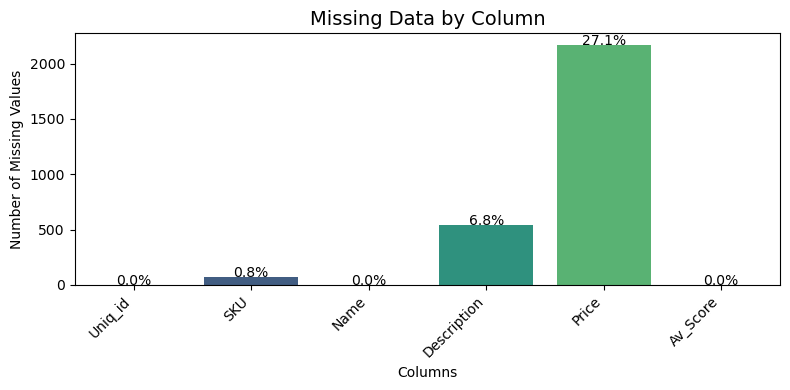

```python
#Looping through the column and count the missing values
missing_values = products_csv_df.isnull().sum()
total_rows = len(products_csv_df)

#print the plot in a bar chart form and display the missing values in each columns
plt.figure(figsize=(8, 4))
ax = sns.barplot(x=missing_values.index, y=missing_values.values, palette="viridis")

#Including percentage labels on each bar
for i, value in enumerate(missing_values.values):
    percent = (value / total_rows) * 100
    ax.text(i, value + 0.5, f"{percent:.1f}%", ha='center', fontsize=10)

#Rotating the names in each columns for a good visibility and including chart labels and formatting
plt.title("Missing Data by Column", fontsize=14)
plt.xlabel("Columns")
plt.ylabel("Number of Missing Values")
plt.xticks(rotation=45, ha='right')
plt.tight_layout()

plt.show()
```

```python
#Checking for missing value in reviews_csv data frame file and print the total number of missing values in each column if there is any and then
#print the number of missing values
print(reviews_csv_df.isnull().sum())
```

```
Uniq_id     0
Username    0
Score       0
Review      0
dtype: int64
```

```python
#Checking for missing value in users_csv data frame file and print the total number of missing values in each column if there is any and then
#print the number of missing values
print(users_csv_df.isnull().sum())
```

```
Username    0
DOB         0
State       0
dtype: int64
```

```python
#Checking if there is any duplicate in the products_csv and if there is count by retruning a boolean where True(1) means Yes and False(0) means No
print(products_csv_df.duplicated().sum())
```

```
0
```

```python
#Checking if there is any duplicate in the reviews_csv and if there is count by retruning a boolean where True(1) means Yes and False(0) means No
print(reviews_csv_df.duplicated().sum())
```

```
0
```

```python
#Checking if there is any duplicate in the users_csv and if there is count by retruning a boolean where True(1) means Yes and False(0) means No
print(users_csv_df.duplicated().sum())
```

```
0
```

**3. Data Visualisation**

```python
#This is a graphical view of the number of customers given birth to on a yearly bases, format the column of data of birth to datetime using the
#day month year approach and extract the year in a new storage namely Year
users_csv_df['Year'] = pd.to_datetime(users_csv_df['DOB'], format='%d.%m.%Y').dt.year

# Group by birth year and count the number of Customers
customer_year  = users_csv_df['Year'].value_counts().reset_index(name='Customer Count')
# print the new table
customer_year.head()
```

|  | Year | Customer Count |
| --- | --- | --- |
| 0 | 1953 | 112 |
| 1 | 1998 | 111 |
| 2 | 1960 | 107 |
| 3 | 1964 | 107 |
| 4 | 1962 | 106 |

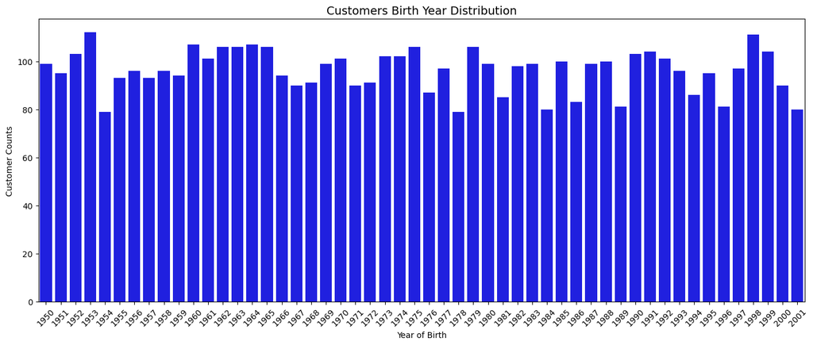

```python
#This is a graphical bar chart view of the number of customers against birth year

#Format the column of data of birth to datetime using the day-month-year approach and extract the year in a new storage namely Year
users_csv_df['Year'] = pd.to_datetime(users_csv_df['DOB'], format='%d.%m.%Y').dt.year
#Count the yearly customer birth and group by year for better understanding
customer_year = users_csv_df['Year'].value_counts().sort_index()

#Form a bar chart displaying the count of yearly born customers
plt.figure(figsize=(14, 6))
sns.barplot(x=customer_year.index, y=customer_year.values, color="blue")
plt.title("Customers Birth Year Distribution", fontsize=14)
plt.xlabel("Year of Birth")
plt.ylabel("Customer Counts")
plt.xticks(rotation=45)
plt.tight_layout()
plt.show()
```

```python
#The count of customers in the state been return in series form where index is the state name, and then convert the series to a data frame using
#pandas library

#Group by state and count the number of Customers in each state
state_counts  = users_csv_df['State'].value_counts().reset_index(name='Customer Counts')

#Display a table with the customer counts across the state
print(state_counts.head())
```

```
                      State  Customer Counts
0             Massachusetts              107
1                  Delaware              106
2                   Vermont              103
3  Northern Mariana Islands              102
4                New Jersey              101
```

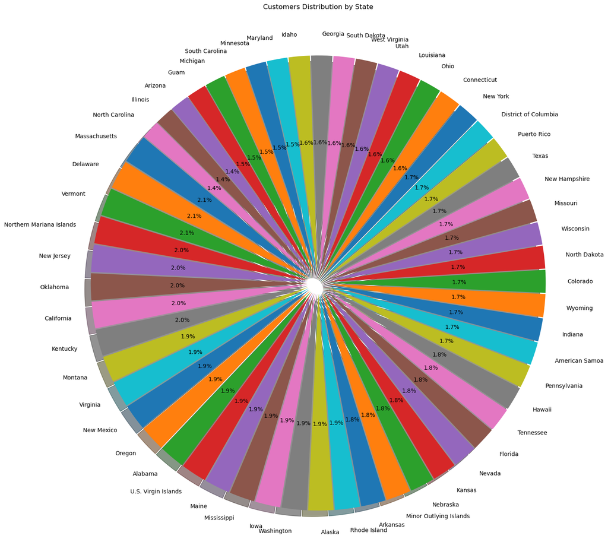

```python
#Plotting each states by the proportion of customers displaying each counts and percentages with the counts of customers statewise

#Count the number of customers within each state
number_of_state = users_csv_df['State'].value_counts()

plt.figure(figsize=(15, 15))
plt.pie(
    number_of_state.values,
    labels=number_of_state.index,
    #Display the percentage on each slices
    autopct='%1.1f%%',
    startangle=140,
    shadow=True,
    explode=[0.05]*len(number_of_state)
)
plt.title("Customers Distribution by State")
plt.tight_layout()
plt.show()
```

```python
#Visualise the products dataset (jcpenney_products_df merged with products_df) showing the products diversity

#Making the column name match within the files
products_json_df.rename(columns={'uniq_id': 'Uniq_id'}, inplace=True)

#Combine both the json and csv dataframe using Uniq_id column
new_product_df = pd.merge(products_json_df, products_csv_df, on='Uniq_id')

#Take any of the columns that has duplicate or not required information
removing_columns = ['Price', 'Description', 'Name', 'sku', 'Av_Score']
new_product_df.drop(columns=removing_columns, inplace=True)

#Take off any rows that still have missing value
new_product_df.dropna(inplace=True)
```

```python
print(new_product_df.head(2))
```

```
                            Uniq_id  \
0  b6c0b6bea69c722939585baeac73c13d
1  93e5272c51d8cce02597e3ce67b7ad0a

                                    name_title  \
0  Alfred Dunner® Essential Pull On Capri Pant
1  Alfred Dunner® Essential Pull On Capri Pant

                                         description list_price sale_price  \
0  You'll return to our Alfred Dunner pull-on cap...      41.09      24.16
1  You'll return to our Alfred Dunner pull-on cap...      41.09      24.16

        category                 category_tree  average_product_rating  \
0  alfred dunner  jcpenney|women|alfred dunner                   2.625
1  alfred dunner  jcpenney|women|alfred dunner                   3.000

                                         product_url  \
0  http://www.jcpenney.com/alfred-dunner-essentia...
1  http://www.jcpenney.com/alfred-dunner-essentia...

                                  product_image_urls          brand  \
0  http://s7d9.scene7.com/is/image/JCPenney/DP122...  Alfred Dunner
1  http://s7d9.scene7.com/is/image/JCPenney/DP122...  Alfred Dunner

   total_number_reviews                                            Reviews  \
0                     8  [{'User': 'fsdv4141', 'Review': 'You never hav...
1                     8  [{'User': 'tpcu2211', 'Review': 'You never hav...

                                         Bought With           SKU
0  [898e42fe937a33e8ce5e900ca7a4d924, 8c02c262567...  pp5006380337
1  [bc9ab3406dcaa84a123b9da862e6367d, 18eb69e8fc2...  pp5006380337
```

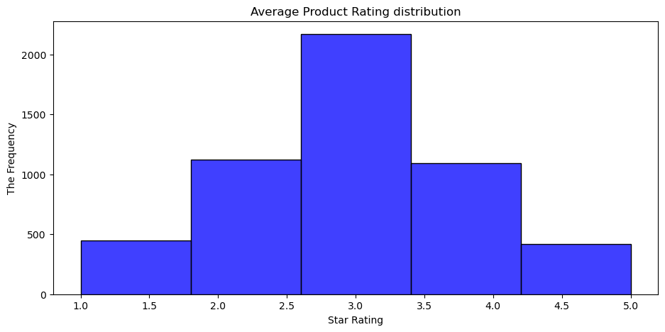

```python
#Printing a histogram that display how frequently each of the average product rate shows
plt.figure(figsize=(11, 5))

# Plotting histogram using seaborn
sns.histplot(
    new_product_df['average_product_rating'],
    bins=5,
    kde=False,
    color = 'blue')
plt.title("Average Product Rating distribution")
plt.xlabel("Star Rating")
plt.ylabel("The Frequency")

#Generate the plot
plt.show()
```

```python
#This code display a table having product’s ID, price list, sale price, and the discount columns, it then creates an empty data to store selected
#pricing data, and it checks if there any invalid numbers and replace it with nan

verified_product_df = (
    new_product_df[["Uniq_id", "list_price", "sale_price"]]
    .rename(columns={'list_price': 'List Price', 'sale_price': 'Sale Price'})
    .assign(Discount=lambda x: pd.to_numeric(x['List Price'], errors='coerce') -
     pd.to_numeric(x['Sale Price'], errors='coerce'))
    .dropna()
)
print(verified_product_df.head(2))
```

```
                            Uniq_id List Price Sale Price  Discount
0  b6c0b6bea69c722939585baeac73c13d      41.09      24.16     16.93
1  93e5272c51d8cce02597e3ce67b7ad0a      41.09      24.16     16.93
```

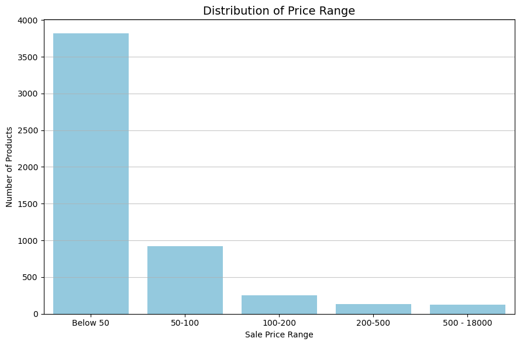

```python
#Displayed graph showing the price range of the products

# Convert 'Sale Price' to numeric values
verified_product_df['Sale Price']= pd.to_numeric(verified_product_df['Sale Price'], errors='coerce')

#state the edge of the bin inline with the price distribution
bin = [0, 50, 100, 200, 500, 18000]
labels = ['Below 50', '50-100', '100-200', '200-500', '500 - 18000']
verified_product_df['Price Range'] = pd.cut(
    verified_product_df['Sale Price'],
    bins=bin,
    labels=labels, right=False)

# Plot a clear histogram
plt.figure(figsize=(9, 6))
sns.countplot(data=verified_product_df, x='Price Range', color='skyblue')

# Add chart details
plt.title("Distribution of Price Range", fontsize=14)
plt.xlabel('Sale Price Range')
plt.ylabel('Number of Products')
plt.grid(axis='y', alpha=0.7)
plt.tight_layout()

# Display the plot
plt.show()
```

```python
# This add the reviewers_json data frame and reviews_cs data information and add up the user's reviews and
# then combine them with their reviewed products and then equate the number of time eacg of the product gets
# reviewed by the customers

#Combining reviewers_json data and reviews_csv data together
combine_the_reviews_data = pd.merge(reviews_csv_df, reviewers_json_df,  on='Username')

#Grouping by the 'Username' and then aggregate the columns
combine_summary_reviews = (
    combine_the_reviews_data.groupby('Username')
    .agg({
        'Uniq_id': lambda x: list(x.unique()),
        'Score': list,
        'Review': lambda x: ', '.join(x.unique()),
        'DOB': lambda x: ', '.join(x.unique()),
        'State': lambda x: list(x.unique())
    })
    .reset_index()
)

#Combine with reviewers dataframe to add the Reviewed products
combine_summary_reviews = pd.merge(
    combine_summary_reviews,
    reviewers_json_df[['Username', 'Reviewed']],
    on='Username'
)

# Combine 'Uniq_id' and 'Reviewed' into one list, then drop 'Uniq_id'
combine_summary_reviews['Reviewed'] = combine_summary_reviews['Uniq_id'] + combine_summary_reviews['Reviewed']

# Count number of reviewed items per user
combine_summary_reviews['Reviewed Items By Count'] = combine_summary_reviews['Reviewed'].apply(len)

# Display final summary
print(combine_summary_reviews.head(2))
```

```
   Username                                            Uniq_id  \
0  aaez2213  [eb5d842eb53ead1323c67c2203f21443, 87fb4c7b6e0...
1  aage1132  [bb95c76db841e59342547712ddf8f5f9, e142c35e406...

                            Score  \
0  [2, 2, 0, 1, 0, 0, 1, 2, 1, 0]
1  [0, 0, 0, 1, 2, 1, 3, 3, 0, 3]

                                              Review         DOB  \
0  The is an excellent shirt. Runs true to size. ...  06.08.1959
1  This dress was good quality, but the pattern a...  06.08.1958

                      State  \
0  [Minor Outlying Islands]
1                [Missouri]

                                            Reviewed  Reviewed Items By Count
0  [eb5d842eb53ead1323c67c2203f21443, 87fb4c7b6e0...                       14
1  [bb95c76db841e59342547712ddf8f5f9, e142c35e406...                       11
```

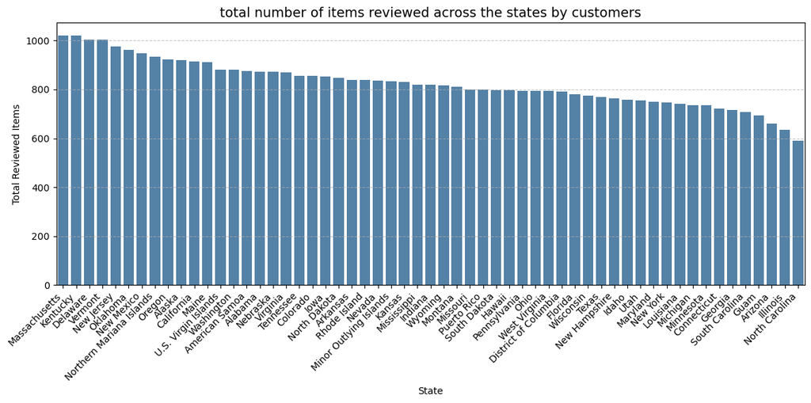

```python
#The overall number of items reviewed by customers in each state

#Calculate the overall reviewed items in each of the states
state_review_totals = (
    combine_summary_reviews.explode('State')
    .groupby('State')['Reviewed']
    #Count the overall items reviewed within each state
    .apply(lambda x: sum(len(i) for i in x))
    .reset_index(name='Total Reviewed Items')
)
#Print a vertical bar chart
plt.figure(figsize=(12, 6))
sns.barplot(
    data=state_review_totals.sort_values('Total Reviewed Items', ascending=False),
    x='State',
    y='Total Reviewed Items',
    color='steelblue'
)
plt.title("total number of items reviewed across the states by customers", fontsize=14)
plt.xlabel("State")
plt.ylabel("Total Reviewed Items")
plt.xticks(rotation=45, ha='right')
plt.grid(axis='y', linestyle='--', alpha=0.7)
plt.tight_layout()

plt.show()
```